1. Exploratory data analysis:
- Write a brief description of the data set you have been given.
- Visualise your time series (time plot, subseries plot, decomposition plot, etc) and discuss the features of the original time series.

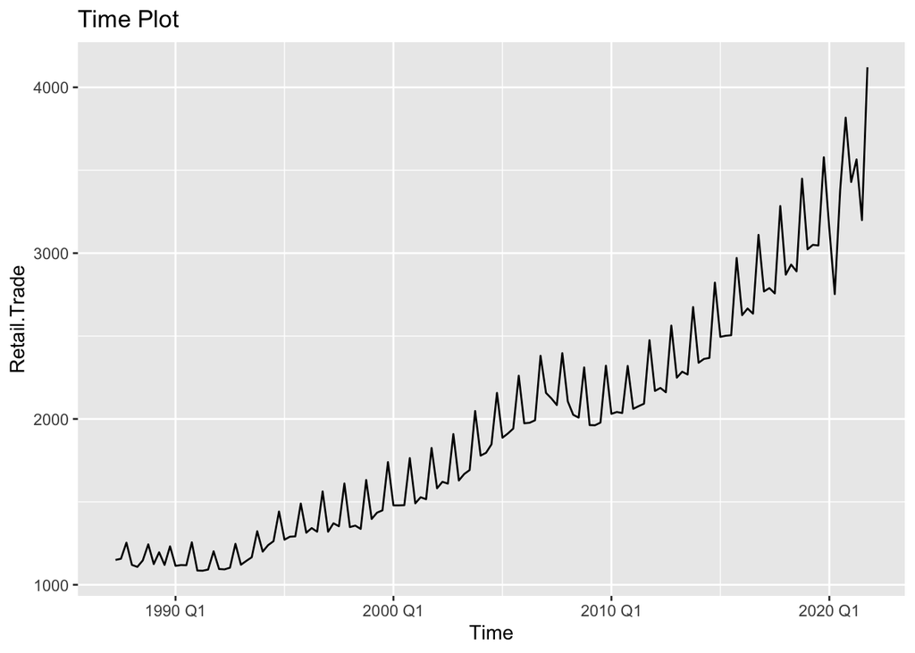

```r
training_data <- read.csv("qgdp_training.csv") %>%
  select(c(Date, Retail.Trade)) %>%
  mutate(Date = yearquarter(Date)) %>%
  as_tsibble(index = Date)
training_data %>%
  autoplot(Retail.Trade) +
  labs(x = "Time",
       y = "Retail.Trade",
       title = "Time Plot")
```

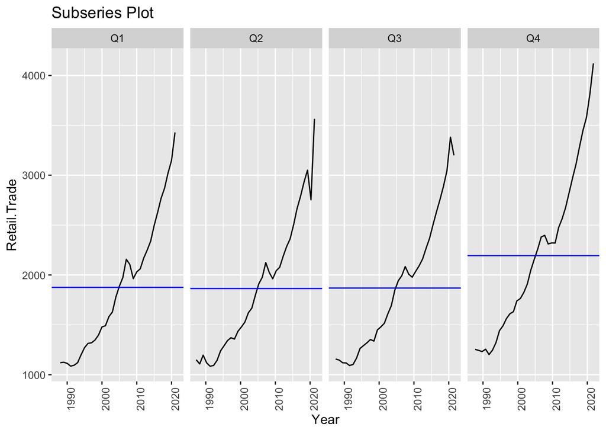

```r
training_data %>%
  gg_subseries(Retail.Trade) +
  labs(x = "Year",
       y = "Retail.Trade",
       title = "Subseries Plot")
```

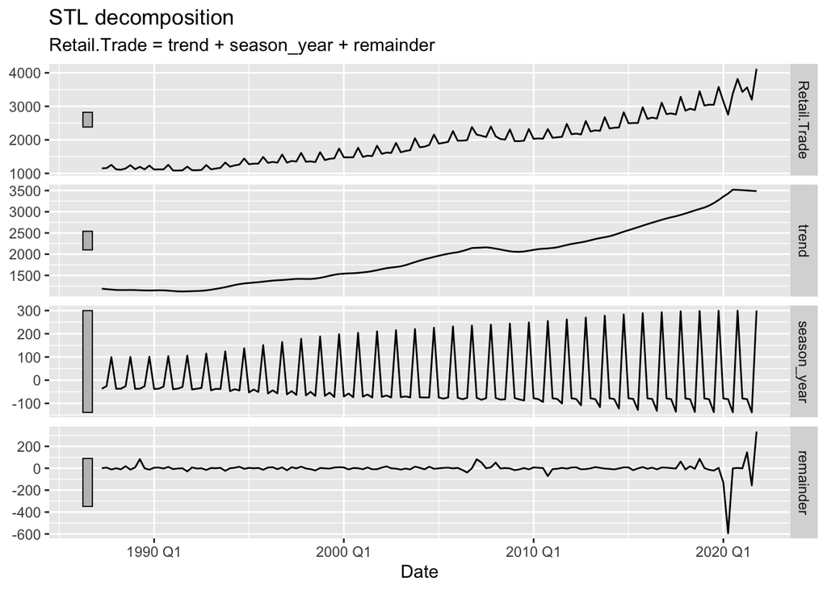

```r
training_data %>%
  model(stl = STL(Retail.Trade, robust = TRUE)) %>%
  components() %>%
  autoplot()
```

2. ETS models: - Explore different ETS models for your data set. - Describe the methodology used to create a shortlist of appropriate candidate ETS models. You are expected to fit these both manually and automatically. - Select the ETS model that you believe has the best predictive ability. Explain your reasons for selecting this model. - Write down the fitted model equations.

```r
# Fit the inferred ETS model
ets_manual_AMA <- training_data %>%
  model(ETS(Retail.Trade ~ error("A") + trend("M") + season("A")))
ets_manual_AAM <- training_data %>%
  model(ETS(Retail.Trade ~ error("A") + trend("A") + season("M")))
ets_manual_AAA <- training_data %>%
  model(ETS(Retail.Trade ~ error("A") + trend("A") + season("A")))
ets_manual_MAN <- training_data %>%
  model(ETS(Retail.Trade ~ error("M") + trend("A") + season("N")))
ets_manual_MAM <- training_data %>%
  model(ETS(Retail.Trade ~ error("M") + trend("A") + season("M")))
ets_manual_MMM <- training_data %>%
  model(ETS(Retail.Trade ~ error("M") + trend("M") + season("M")))
ets_auto <- training_data %>%
  model(ETS(Retail.Trade))

# Compare the AIC values of the models
aic_values <- bind_rows(
  ets_manual_AMA %>% glance() %>% mutate(Model = "ETS(AMA)"),
  ets_manual_AAM %>% glance() %>% mutate(Model = "ETS(AAM)"),
  ets_manual_AAA %>% glance() %>% mutate(Model = "ETS(AAA)"),
  ets_manual_MAN %>% glance() %>% mutate(Model = "ETS(MAN)"),
  ets_manual_MAM %>% glance() %>% mutate(Model = "ETS(MAM)"),
  ets_manual_MMM %>% glance() %>% mutate(Model = "ETS(MMM)"),
  ets_auto %>% glance() %>% mutate(Model = "ETS(Auto)")
) %>% arrange(AIC)

print(aic_values)
```

```
## # A tibble: 7 × 10
##   .model            sigma2 log_lik   AIC  AICc   BIC    MSE   AMSE     MAE Model
##   <chr>              <dbl>   <dbl> <dbl> <dbl> <dbl>  <dbl>  <dbl>   <dbl> <chr>
## 1 "ETS(Retail.Tra… 8.79e-4   -894. 1805. 1807. 1832.  5574.  6199.  0.0195 ETS(…
## 2 "ETS(Retail.Tra… 8.79e-4   -894. 1805. 1807. 1832.  5574.  6199.  0.0195 ETS(…
## 3 "ETS(Retail.Tra… 8.79e-4   -894. 1806. 1807. 1832.  5599.  6181.  0.0193 ETS(…
## 4 "ETS(Retail.Tra… 5.23e+3   -934. 1886. 1887. 1912.  4927.  5841. 41.4    ETS(…
## 5 "ETS(Retail.Tra… 6.73e+3   -951. 1921. 1922. 1947.  6338.  6966. 48.1    ETS(…
## 6 "ETS(Retail.Tra… 6.76e+3   -952. 1921. 1923. 1948.  6367.  6947. 49.1    ETS(…
## 7 "ETS(Retail.Tra… 6.52e-3  -1035. 2080. 2081. 2095. 29813. 28719.  0.0637 ETS(…
```

```r
# Select the model with the lowest AIC value
best_model_name <- aic_values %>% slice(1) %>% pull(Model)
best_model <- switch(best_model_name,
  "ETS(AMA)" = ets_manual_AMA,
  "ETS(AAM)" = ets_manual_AAM,
  "ETS(AAA)" = ets_manual_AAA,
  "ETS(MAN)" = ets_manual_MAN,
  "ETS(MAM)" = ets_manual_MAM,
  "ETS(MMM)" = ets_manual_MMM,
  "ETS(Auto)" = ets_auto
)

# Print the best model equation
best_model_equation <- best_model %>%
  report()
```

```
## Series: Retail.Trade
## Model: ETS(M,A,M)
##   Smoothing parameters:
##     alpha = 0.403321
##     beta  = 0.07330283
##     gamma = 0.1493439
##
##   Initial states:
##      l[0]      b[0]      s[0]   s[-1]     s[-2]     s[-3]
##  1168.818 -2.777311 0.9594427 1.08881 0.9763337 0.9754133
##
##   sigma^2:  9e-04
##
##      AIC     AICc      BIC
## 1805.476 1806.872 1831.887
```

```r
print(best_model_equation)
```

```
## # A mable: 1 x 1
##   `ETS(Retail.Trade ~ error("M") + trend("A") + season("M"))`
##                                                       <model>
## 1                                                <ETS(M,A,M)>
```

3. ARIMA models:
- Explore different ARIMA models for your data set.
- Provide an explanation of any transformations and differencing required.
- Describe the methodology used to create a shortlist of appropriate candidate ARIMA models. You are expected to fit these both manually and automatically.
- Select the ARIMA model that you believe has the best predictive ability. Explain your reasons for selecting this model.
- Write down the fitted model equation in backshift notation.

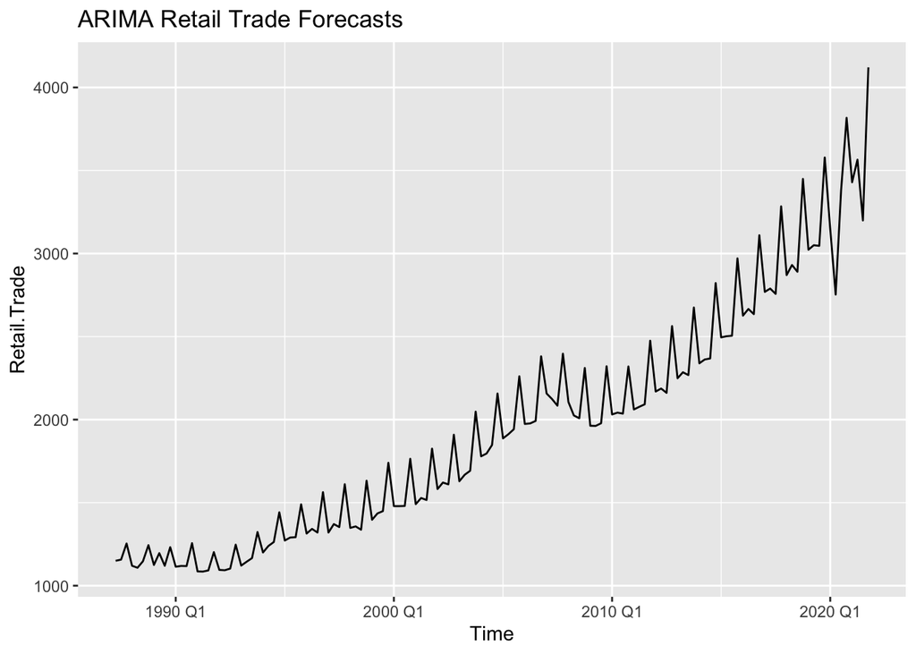

```r
ARIMA_data <- training_data
ARIMA_data %>% autoplot(Retail.Trade) + labs(title = "ARIMA Retail Trade Forecasts", x = "Time", y = "Retail.Trade")
```

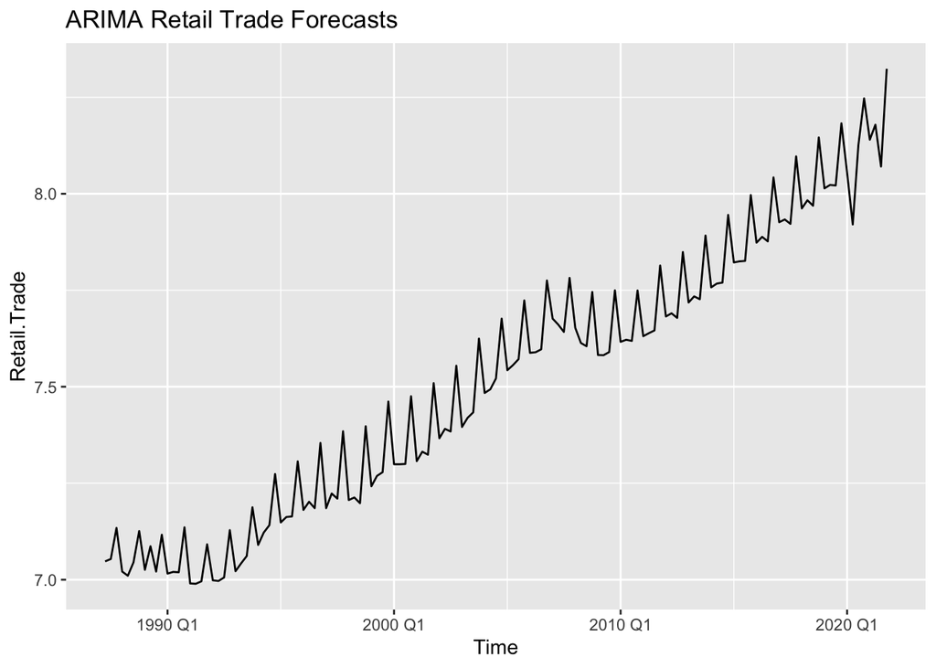

```r
# Provide an explanation of log transformations and differencing required.
ARIMA_data %>% autoplot(log(Retail.Trade)) + labs(title = "ARIMA Retail Trade Forecasts", x = "Time", y = "Retail.Trade")
```

```r
# These functions suggest we should apply only one seasonal difference(no first difference).
ARIMA_data %>%
  mutate(log_Retail_Trade = log(Retail.Trade)) %>% features(log_Retail_Trade, unitroot_nsdiffs)
```

```
## # A tibble: 1 × 1
##   nsdiffs
##     <int>
## 1       1
```

```r
ARIMA_data %>%
  mutate(d_log_Retail_Trade = difference(log(Retail.Trade), 12)) %>%
  features(d_log_Retail_Trade, unitroot_ndiffs)
```

```
## # A tibble: 1 × 1
##   ndiffs
##    <int>
## 1      0
```

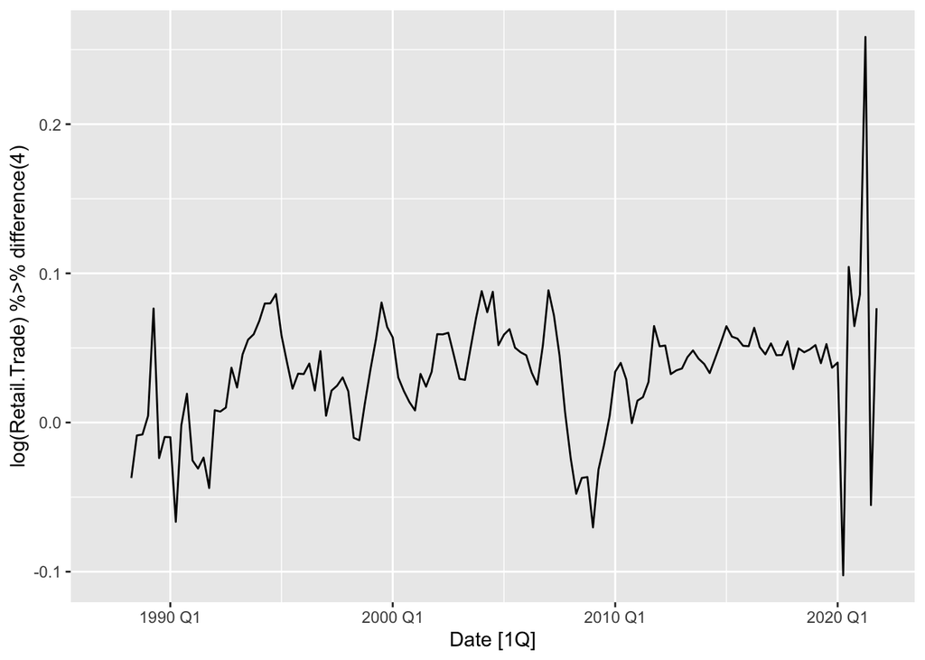

```r
# Check whether it is a stationary time series
ARIMA_data %>% autoplot(log(Retail.Trade) %>% difference(4))
```

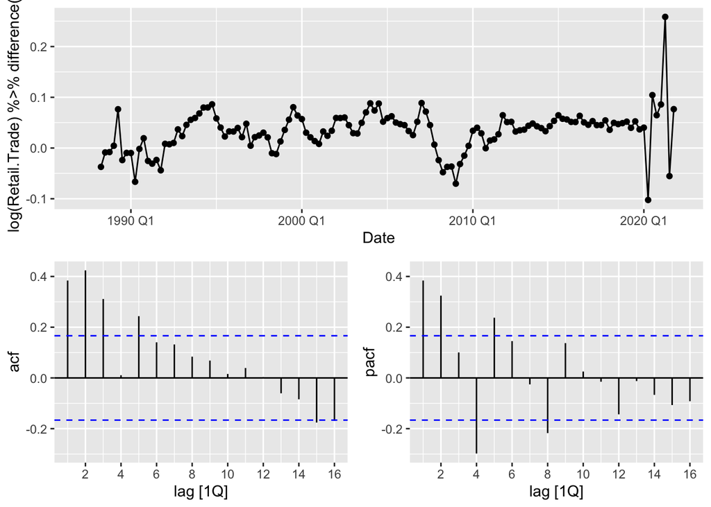

```r
# Plot the ACF/PACF of the differenced data and try to determine possible candidate models.
ARIMA_data %>% gg_tsdisplay(log(Retail.Trade)%>% difference(4),plot_type = "partial", lag_max = 16)
```

```r
# Fit these both manually and automatically.
# Features of an AR(p) model the ACF is exponentially decaying or sinusoidal. There is a significant spike at lag p in the PACF, but none beyond lag p.
# Features of an MA(q) model there is a significant spike at lag q in the ACF, but none beyond lag q. The PACF is exponentially decaying or sinusoidal.
ARIMA_fit <- ARIMA_data %>%
  model(auto = ARIMA(log(Retail.Trade), stepwise = FALSE, approximation = FALSE),
        arima200210 = ARIMA(log(Retail.Trade) ~ pdq(2,0,0) + PDQ(2,1,0)),
        arima201210 = ARIMA(log(Retail.Trade) ~ pdq(2,0,1) + PDQ(2,1,0)),
        arima202210 = ARIMA(log(Retail.Trade) ~ pdq(2,0,2) + PDQ(2,1,0)),
        arima003210 = ARIMA(log(Retail.Trade) ~ pdq(0,0,3) + PDQ(2,1,0)))

# We select the best models by minimizing the AIC, AICc or BIC. We would prefer to use AICc.
glance(ARIMA_fit) %>% arrange(AICc) %>% select(.model:BIC)
```

```
## # A tibble: 5 × 6
##   .model        sigma2 log_lik   AIC  AICc   BIC
##   <chr>          <dbl>   <dbl> <dbl> <dbl> <dbl>
## 1 auto        0.000797    291. -566. -565. -543.
## 2 arima202210 0.000797    291. -566. -565. -543.
## 3 arima200210 0.000868    285. -558. -558. -541.
## 4 arima201210 0.000874    285. -557. -556. -536.
## 5 arima003210 0.000963    279. -544. -543. -524.
```

```r
# Details of the optimal model are given
best_ARIMA_model <- ARIMA_fit %>% select(auto)
report(best_ARIMA_model)
```

```
## Series: Retail.Trade
## Model: ARIMA(2,0,2)(2,1,0)[4] w/ drift
## Transformation: log(Retail.Trade)
##
## Coefficients:
##          ar1      ar2      ma1     ma2     sar1     sar2  constant
##       1.8112  -0.8481  -1.4182  0.6660  -1.0612  -0.5813    0.0033
## s.e.  0.0790   0.0768   0.0878  0.0825   0.1067   0.1092    0.0006
##
## sigma^2 estimated as 0.0007973:  log likelihood=291.24
## AIC=-566.49   AICc=-565.34   BIC=-543.24
```

4. Neural network autoregression (NNAR) models:
- In Chapter 12 of the fpp3 online textbook, there is an advanced topic on the Neural Network Autogregressive (NNAR) model.
- Read this chapter and any other materials that will help you understand the NNAR model.
- In your own words, explain the NNAR model as if you were teaching it to your fellow classmates.
- Fit an automatic NNAR model to your data set and report the fitted model.

```r
fit_NNAR <- training_data %>%
  model(NNETAR(Retail.Trade)) %>%
  report()
```

```
## Series: Retail.Trade
## Model: NNAR(7,1,4)[4]
##
## Average of 20 networks, each of which is
## a 7-4-1 network with 37 weights
## options were - linear output units
##
## sigma^2 estimated as 1506
```

5. Assumption checking:
- Produce residual diagnostic plots for your three chosen models (ETS, ARIMA, NNAR).
- Do not perform a Box-Pierce or Ljung-Box test.
- Research the topic of surrogate data testing in time series, specifically, the Random Shuffle method. Explain this test for independence as if you were teaching it to your fellow classmates.
- Test the independence of your residuals (or innovation residuals) using the surrogate_test.R code provided. Explain how the R code works.

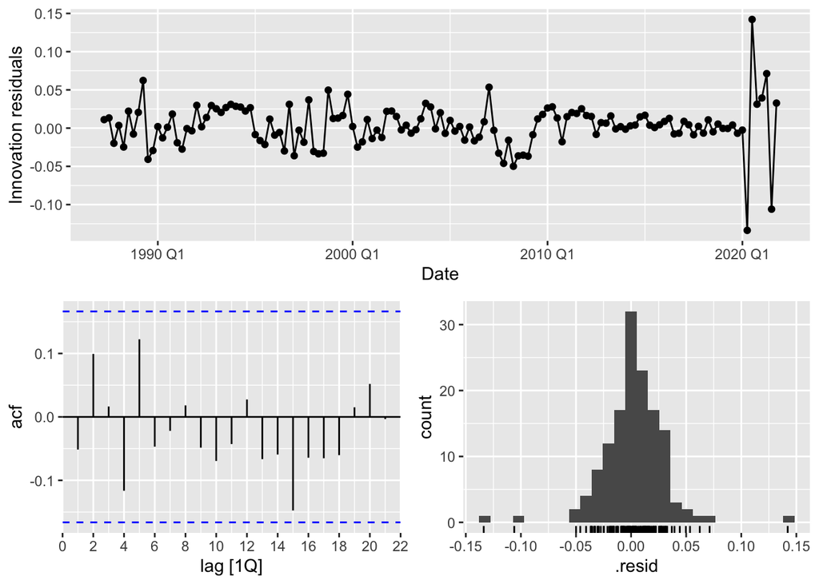

```r
source("surrogate_test.R")
# Assumption checking
residuals_MAM <- residuals(ets_manual_MAM, lag_max= 8)
gg_tsresiduals(ets_manual_MAM)
```

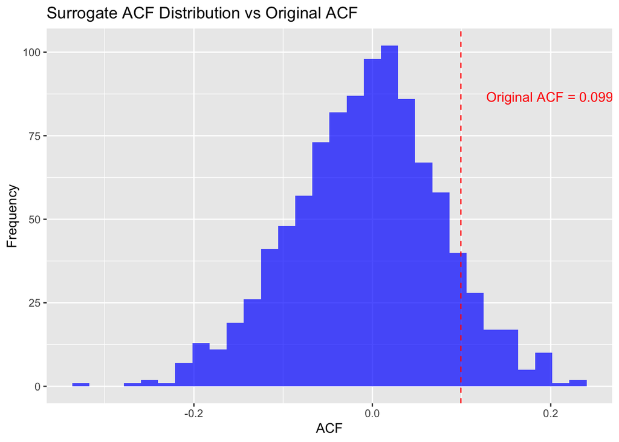

```r
set.seed(1)
n_simulations <- 1000

# Calculate the autocorrelation of the original residuals
original_acf <- residuals_MAM %>% ACF(var = .resid) %>% pull(acf) %>% .[2]
surrogate_acfs <- replicate(n_simulations, {
  shuffled_residuals <- sample(residuals_MAM$.resid)
  acf(shuffled_residuals, plot = FALSE)$acf[2]
})

# Draw a comparison chart of the autocorrelations of the original residuals and the substituted residuals
surrogate_acfs_df <- tibble(acf = surrogate_acfs)
p4 <- surrogate_acfs_df %>%
  ggplot(aes(x = acf)) +
  geom_histogram(bins = 30, fill = "blue", alpha = 0.7) +
  geom_vline(xintercept = original_acf, color = "red", linetype = "dashed") +
  ggtitle("Surrogate ACF Distribution vs Original ACF") +
  labs(x = "ACF", y = "Frequency") +
  annotate("text", x = original_acf, y = max(table(cut(surrogate_acfs, breaks = 30))),
           label = paste("Original ACF =", round(original_acf, 3)),
           vjust = 2, hjust = -0.2, color = "red")
print(p4)
```

```r
# p-value
p_value <- mean(abs(surrogate_acfs) >= abs(original_acf))
cat("P-value for the independence test:", p_value, "\n")
```

```
## P-value for the independence test: 0.229
```

```r
if (p_value < 0.05) {
  cat("The test rejects the null hypothesis of independence (p-value < 0.05).\n")
} else {
  cat("The test does not reject the null hypothesis of independence (p-value >= 0.05).\n")
}
```

```
## The test does not reject the null hypothesis of independence (p-value >= 0.05).
```

```r
# test
lag <- 8
surrogate_result <- surrogate.test(residuals_MAM, lag = lag, N = 1000, test.stat = "ljung-box")
print(surrogate_result)
```

[output not shown]

[output cut: 165 more lines]

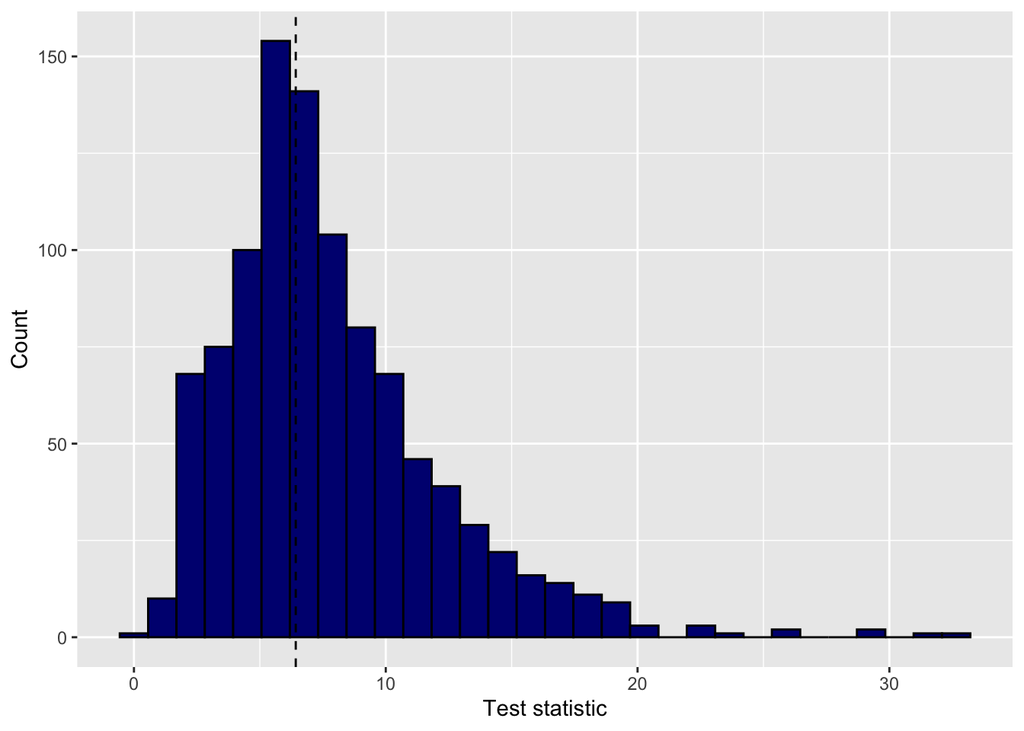

```r
plot.surrogate(surrogate_result)
```

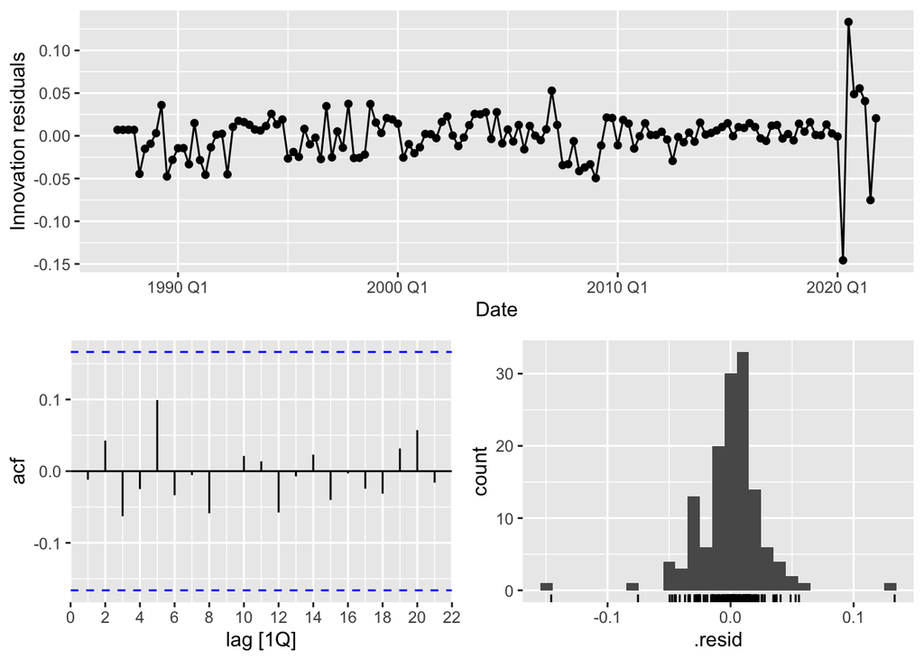

```r
#Check the residuals from your chosen model by plotting the ACF of the residuals.
best_ARIMA_model %>% gg_tsresiduals()
```

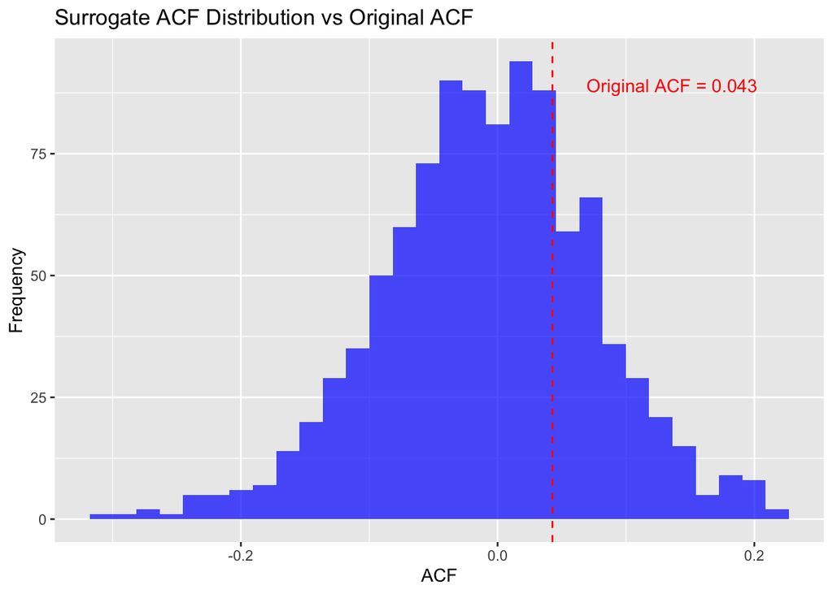

```r
#Research the topic of surrogate data testing in time series
ARIMA_residuals <- residuals(best_ARIMA_model)

# 设定随机种子和模拟次数
set.seed(123)
n_simulations <- 1000

# 计算原始残差的自相关性
original_acf <- ARIMA_residuals %>% ACF(var = .resid) %>% pull(acf) %>% .[2]
# 生成替代数据并计算自相关性
surrogate_acfs <- replicate(n_simulations, {
  shuffled_residuals <- sample(ARIMA_residuals$.resid)
  acf(shuffled_residuals, plot = FALSE)$acf[2]
})

# 绘制原始残差和替代残差自相关性的比较图
surrogate_acfs_df <- tibble(acf = surrogate_acfs)
p4 <- surrogate_acfs_df %>%
  ggplot(aes(x = acf)) +
  geom_histogram(bins = 30, fill = "blue", alpha = 0.7) +
  geom_vline(xintercept = original_acf, color = "red", linetype = "dashed") +
  ggtitle("Surrogate ACF Distribution vs Original ACF") +
  labs(x = "ACF", y = "Frequency") +
  annotate("text", x = original_acf, y = max(table(cut(surrogate_acfs, breaks = 30))),
           label = paste("Original ACF =", round(original_acf, 3)),
           vjust = 2, hjust = -0.2, color = "red")
print(p4)
```